MA. Language Analysis and Processing  
*In a Vector Space of La Mancha, whose Position I Do Wish to Recall:*  
*A comprehensive Evaluation of Word Embeddings*  
María García-Abadillo Velasco

# Data Preprocessing and Exploratory Data Analysis

[figure not shown]

*Map of La Solana and the surrounding area, ca. 1773*

# Table of Contents

## Introduction

This notebook presents the steps taken to clean and preprocess our data for word embedding training, as well as an exploratory data analysis of each subcorpus and the final dataset. We believe that cleaning up the data is an essential step for any machine or deep learning project, even if it does not always receive the spotlight. Therefore, we have combined these three sections to provide a better understanding of our input data.

A separate notebook dedicated to the training process can be found in the GitHub repository.

```python
import re
from nltk.tokenize import sent_tokenize
import random
import string
import pandas
import threading
import numpy as np
import matplotlib.pyplot as plt

from utils_preprocessing import (
    preprocess_sentences,
    interleave_lists,
    get_stats,
    sentences_into_flat_tokens,
    get_advanced_tokens,
    plot_custom_boxplot,
)
```

## La Gaceta de La Solana

The Gaceta de La Solana is a bi-monthly printed newspaper with a tradition spanning over 50 years. Certain editions have surpassed 100 pages, covering a wide array of topics pertaining to the political, societal, and economic aspects of La Villa de La Solana, located in Ciudad Real.

For our purposes, 205 PDF editions from the Ayuntamiento de La Solana and [Biblioteca Virtual de Castilla-La Mancha webpages](https://ceclmdigital.uclm.es/results.vm?q=parent:0002509276&lang=es&view=global) were downloaded and stored in a folder and converted into TXT files with the open-source command-line utility `pdftotext`.

```
for pdf_file in '$input_directory'*.pdf; do
    base_name=$(basename '$pdf_file; .pdf)
    output_text_file='$output_directory${base_name}.txt'
    pdftotext -enc UTF-8 '$pdf_file' '$output_text_file'
```

Although this tool did a better job than others when converting PDFs to text than other python libraries, the original files present a challenge due to the inclusion of advertisements, tables, and typical newspaper formatting that is difficult to convert. This has resulted in some noise in our data. We will address this during preprocessing, but some inconsistencies could not be resolved automatically.

### Preprocessing

```python
with open("all_gacetas.txt", "r") as file:
    gacetas = file.read()
```

We remove hyphens and spaces that were necessary in the orignal text display (usually double column).

```python
matches = re.findall(r".*\w-\n", gacetas)
print(len(matches))
```

```
13271
```

```python
replaced_hyphen = re.sub(r"(\w)-\n+", r"\1", gacetas).lower()
# remove sentences 'Biblioteca Virtual (...)
matches_publicado = re.sub(r"biblioteca virtual.*\n", "", replaced_hyphen)
# remove unnecessary spaces.
gacetas_stripped = re.sub(r"\n+|\s+|\t+", " ", matches_publicado).strip()
# remove all hyphen but those between characters, as in 'garcía-abadillo'
surname_hyphen = re.sub(r"(?<!\w)-(?!\w)", "", gacetas_stripped)
other_hyphen = re.sub(r"-\s|\s-", "", surname_hyphen)
# remove noisy sentences, often a bad conversion of ads
ad_remove = re.sub(r"[~•·].*?\.", "", other_hyphen)
```

```python
len(ad_remove)
```

```
22315195
```

Next, we tokenize the data into sentences, as sentences is what the librarty `fasttext` is expecting as an input for training word embeddings. We prepared our own list of symbols and replaced all numbers by the token `[NUM]`.

```python
sentences_gaceta = preprocess_sentences(ad_remove)
```

The next snippet prints random sentences to inspect our data and check that most problems are solved.

```python
num = random.randrange(0, 156508)
print(sentences_gaceta[num])
```

```
la despoblación también es un fenómeno significativo que impacta profundamente en la vida y sostenibilidad de esta región
```

Finally, the data is saved into a text file, separated by a newline character.

```python
# file_path = "all_gacetas_preprocessed.txt"
# with open(file_path, "w", encoding='utf-8') as file:
# for sentence in sentences_gace:
# file.write(sentence + "\n")
```

### Sentence Statistics

```python
gaceta_stats = get_stats(sentences_gaceta)
```

```
Total sentences: 154623
Average sentence length: 141
Minimum sentence length: 1
Maximum sentence length: 2215
Percentile 25, length: 67.0
Percentile 50, length: 184.0
```

### Token Statistics

```python
gacetas_tokens_list, gacetas_tokens_flat = sentences_into_flat_tokens(sentences_gaceta)
gaceta_tokens_stats = get_advanced_tokens(gacetas_tokens_list, gacetas_tokens_flat)
```

```
Total number of tokens: 3724913
Average sentence length (tokens): 24
Minimum sentence length (tokens): 1
Maximum sentence length (tokens): 376
Percentile 25, length: 12.0
Percentile 75, length: 31.0
```

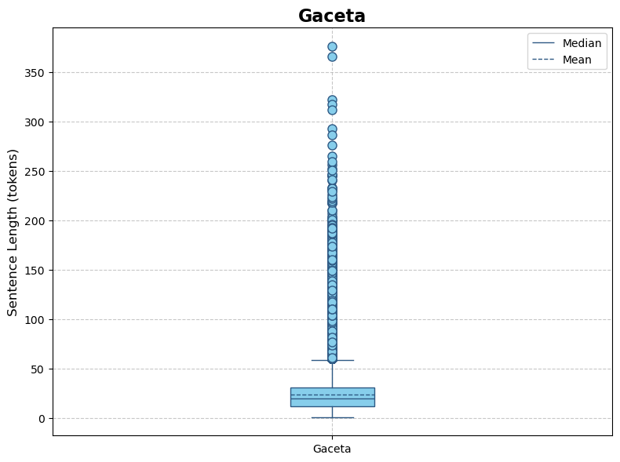

```python
gaceta_data = [len(sentence) for sentence in gacetas_tokens_list]
plot_custom_boxplot(gaceta_data, "Gaceta")
```

## La Solana News Dataset

La Solana News Dataset consists of 1070 news articles in Spanish extracted from the 'News' section of the [La Solana City Council official website](https://www.lasolana.es/laciudad/noticias). The Python libraries `bs4`, `rllib.parse`, and `newspaper` were used to collect and structure the data. Finally, manually annotate the data into seven clases. For training the word embeddings, we will use the columns 'Title' and 'Text'.

### Data Extraction and Preprocessing

```python
dataset = pandas.read_csv("lasolana_dataset.csv")
```

```python
titles = dataset["Title"]
text = dataset["Text"]
```

Next, we will create a function that iteratively joins each title to its article in our txt file, so they appear one after another.

```python
result_list = []

thread = threading.Thread(target=interleave_lists, args=(titles, text, result_list))
thread.start()
thread.join()
```

This return a list of strings. Because we want a unique string to perform sentece tokenization, the strings will be concatenated with a white space.

```python
concatenated_string = " ".join(result_list).lower()
```

The punctuation is removed and the numbers are replaced with the number token.

```python
sentences_articles = preprocess_sentences(concatenated_string)
```

```python
num = random.randrange(0, 1000)
print(sentences_articles[num])
```

```
en cuanto a los blancos las expectativas son algo mejores tanto en cosecha como en precio
```

Finally, we save the preprocessed document in a txt file.

```python
# txt = '\n'.join(sentences)
# with open('articles.txt', 'w', encoding='utf-8') as file:
# file.write(txt)
```

### Sentece Statistics

```python
articles_stats = get_stats(sentences_articles)
```

```
Total sentences: 13402
Average sentence length: 154
Minimum sentence length: 2
Maximum sentence length: 1621
Percentile 25, length: 94.0
Percentile 50, length: 196.0
```

### Token Statistics

```python
articles_tokens_list, articles_tokens_flat = sentences_into_flat_tokens(
    sentences_articles
)
articles_tokens_stats = get_advanced_tokens(articles_tokens_list, articles_tokens_flat)
```

```
Total number of tokens: 352676
Average sentence length (tokens): 26
Minimum sentence length (tokens): 1
Maximum sentence length (tokens): 205
Percentile 25, length: 16.0
Percentile 75, length: 33.0
```

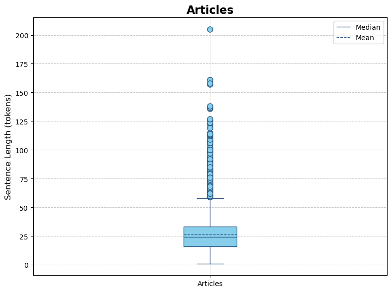

```python
articles_data = [len(sentence) for sentence in articles_tokens_list]
plot_custom_boxplot(articles_data, "Articles")
```

## Julián Simón Blogspot

Julián Simón held the position of town mayor in La Solana from 1983 to 1987 and he was also a teacher. Starting from 2012 until 2019, he authored a digital blog called '[Joaquin Costa. La Solana. Legado Bustillo](https://joaquincostalasolanalegadobustillo.blogspot.com/)' with the objective of promoting the history and cultural heritage of La Solana. The entries of this blog are characterized by their linguistic precision and use of specialized in-domain terminology related to the town's traditions and culture. This makes the data high-quality for our training purposes.

### Preprocessing

The same proceadure as in the last two resources will be followed:

- Cleaning of specific markdown (blogspot markdown in this case)
- Setence Tokenization
- Number replacement by token [NUM]
- Saving the strings into a TXT file

```python
with open("blogsimón_raw", encoding="utf-8") as txt:
    data = txt.read()
```

```python
# Remove blogspot markdown
matches_publicado = re.sub(r"Publicado.*\n", "", data)
matches_comentario = re.sub(
    r"\d Añadir un comentario|\d Ver comentarios", "", matches_publicado
)
matches_day = re.sub(r"\d\n", "", matches_comentario)
matches_month = re.sub(
    r"MAY|APR|JUN|JUL|SEP|NOV|AUG|OCT|JAN|DEC|FEB|MAR\n", "", matches_day
)

# Remove unexpected 2 at the beginning of some sentences
dos_word = re.sub(
    r"(?<!\S)2", "", matches_month
)  # matches the character "2" only if it's at the beginning of a line or preceded by whitespace

# Remove extra whitespaces
text_stripped = re.sub(r"\n+|\s+", " ", dos_word).strip()
data_processed = text_stripped.lower()
```

```python
sentences_blogspot = preprocess_sentences(data_processed)
```

```python
num = random.randrange(0, 1000)
print(sentences_blogspot[num])
```

```
azafranales en plena floración en terrenos de labor situados en los alrededores de la solana en la zona de la moheda principalmente
```

```python
# file_path = "blogspot_preprocess.txt"

# with open(file_path, "w", encoding='utf-8') as file:
# for sentence in sentences:
# file.write(sentence + "\n")
```

### Sentence Statistics

```python
blogspot_stats = get_stats(sentences_blogspot)
```

```
Total sentences: 2397
Average sentence length: 214
Minimum sentence length: 1
Maximum sentence length: 2837
Percentile 25, length: 80.0
Percentile 50, length: 267.0
```

### Token Statistics

```python
blogspot_tokens_list, blogspot_tokens_flat = sentences_into_flat_tokens(
    sentences_blogspot
)
blogspot_tokens_stats = get_advanced_tokens(blogspot_tokens_list, blogspot_tokens_flat)
```

```
Total number of tokens: 91287
Average sentence length (tokens): 38
Minimum sentence length (tokens): 1
Maximum sentence length (tokens): 545
Percentile 25, length: 14.0
Percentile 75, length: 49.0
```

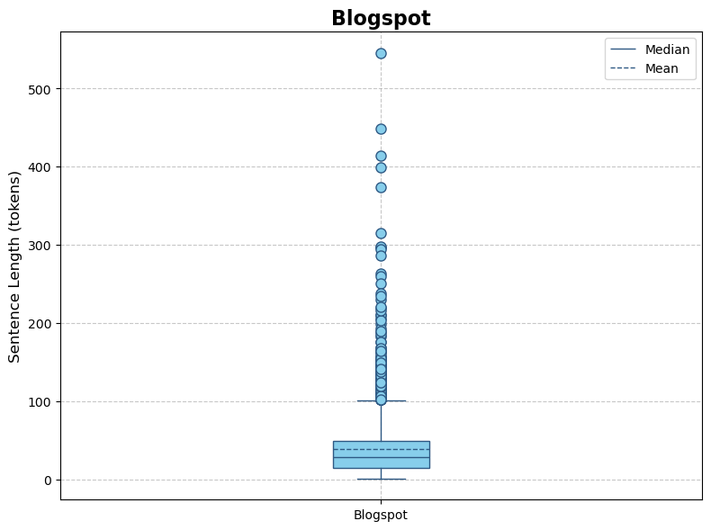

```python
blogspot_data = [len(sentence) for sentence in blogspot_tokens_list]
plot_custom_boxplot(blogspot_data, "Blogspot")
```

## Book: *El legado Bustillo de La Solana : su fundación, visicitudes, intervención de Costa, asesinato del cura Torrijos, situación actual.*

The book about Legado Bustillo dates back to 1935 and was written by Jose María García Gallego, a doctor who wrote about a controversial lawsuit that occurred in La Solana at the beginning of the last century. The lawsuit brought the acclaimed politician and lawyer Joaquín Costa to the town. Not much is known about the author beyond this.

The document is available as a PDF in [Biblioteca Virtual de Castilla-La Mancha](https://ceclmdigital.uclm.es/results.vm?q=id:0000330120&lang=es&view=libros).

Once again, the same preprocessing steps will be carried out.

```python
with open("legado_raw.txt", encoding="utf-8") as txt:
    data = txt.read()
```

```python
data = data.lower()
matches_publicado = re.sub(r"biblioteca virtual.*\n", "", data)
text_stripped = re.sub(r"\n+|\s+", " ", matches_publicado).strip()
```

```python
sentences_book = preprocess_sentences(text_stripped)
```

```python
num = random.randrange(0, 300)
print(sentences_book[num])
```

```
casa de la media naranja donde vivieron y murieron los fundadores del legado
```

Finally, the strings are saved into a TXT file.

```python
# txt = '\n'.join(sentences)
# with open('book.txt', 'w', encoding='utf-8') as file:
# file.write(txt)
```

### Sentence Statistics

```python
bustillo_stats = get_stats(sentences_book)
```

```
Total sentences: 372
Average sentence length: 227
Minimum sentence length: 2
Maximum sentence length: 2353
Percentile 25, length: 86.75
Percentile 50, length: 287.75
```

### Token Statistics

```python
bustillo_tokens_list, bustillo_tokens_flat = sentences_into_flat_tokens(sentences_book)
bustillo_tokens_stats = get_advanced_tokens(bustillo_tokens_list, bustillo_tokens_flat)
```

```
Total number of tokens: 14652
Average sentence length (tokens): 39
Minimum sentence length (tokens): 1
Maximum sentence length (tokens): 406
Percentile 25, length: 15.75
Percentile 75, length: 50.0
```

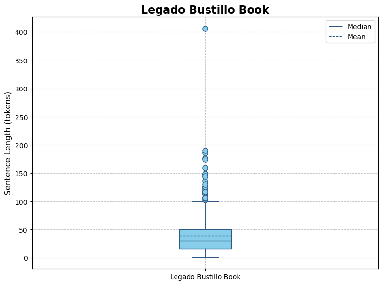

```python
bustillo_data = [len(sentence) for sentence in bustillo_tokens_list]
plot_custom_boxplot(bustillo_data, "Legado Bustillo Book")
```

## Corpus

The subcorpora presented above was merged into a single txt in the command line using the following command:

```
cat /path/to/folder/*.txt > corpus.txt
```

And the following words were joined with an underscore to count them as multiword tokens using the `replace_tokens_in_corpus` function.

```
fs la solana,fs_la_solana
cb la solana,cb_la_solana
cf la solana,cf_la_solana
ff la solana,ff_la_solana
llanos del caudillollanos_del_caudillo
san carlos del valle,san_carlos_del_valle
argamasilla de alba,argamasilla_de_alba
la solana,la_solana
ciudad real,ciudad_real
pozo de la serna,pozo_de_la_serna
alcázar de san juan,alcázar_de_san_juan
partido popular,partido_popular
izquierda unida,izquierda_unida
partido socialista,partido_socialista
guardia civil,guardia_civil
policía local,policía_local
garcía maroto,garcía_maroto
el humilladero,el_humilladero
javier paulino,javier_paulino
romero peña,romero_peña
federico romero,federico_romero
sagrado corazón,sagrado_corazón
el santo,el_santo
modesto navarro,modesto_navarro
clara campoamor,clara_campoamor
universidad popular,universidad_popular
legado bustillo,legado_bustillo
cruz roja,cruz_roja
san sebastián,san_sebastián
semana santa,semana_santa
```

```python
with open("corpus.txt", encoding="utf-8") as txt:
    corpus = txt.readlines()
```

### Post-processing

After conducting EDA on each subcorpus, we examined sentences with a higher number of tokens to gain a better understanding of their content. We discovered that some of these lengthy sentences were a result of the conversion process from PDF to TXT or the scraping process. By removing certain control characters, we were able to facilitate the sentence tokenizer function and split these sentences into smaller, more manageable units. However, we decided to keep other sentences that were not automatically separable because they still carried important linguistic information.

We believe that the results of the embedding evaluation will shed light on the success of this data cleaning and preprocessing approach.

```python
# sentence_lengths = [len(sentence) for sentence in corpus_tokens_list]
# max_idx = np.argmax(sentence_lengths)

# max_idxs = np.argsort(sentence_lengths)[::-1][:30]
# longest_sentences = ''
# for idx in max_idxs:
# print(f"spam longest sentence index: {idx}\n{corpus[idx]}")
# print()
# print('---------------------------------------------------')
# print()

# x = corpus[117462]
# y = corpus[117463]
# z =x + y
# no_x07 = re.sub(r'\s?\x07\s?', '', z)
# no_hyphen = re.sub(r'–', '.', no_x07)
```

### Sentence Statistics

```python
corpus_stats = get_stats(corpus)
```

```
Total sentences: 170796
Average sentence length: 145
Minimum sentence length: 1
Maximum sentence length: 2837
Percentile 25, length: 70.0
Percentile 50, length: 187.0
```

### Tokens Statistics

```python
corpus_tokens_list, corpus_tokens_flat = sentences_into_flat_tokens(corpus)
corpus_tokens_stats = get_advanced_tokens(corpus_tokens_list, corpus_tokens_flat)
```

```
Total number of tokens: 4133505
Average sentence length (tokens): 24
Minimum sentence length (tokens): 0
Maximum sentence length (tokens): 543
Percentile 25, length: 12.0
Percentile 75, length: 31.0
```

In the boxplot below, outliers regarding length remain, which could not be removed using regular expressions. However, we believe that this does not necessarily have a negative effect on our embedding training. If we were to build another NLP model, we should rethink the approach.

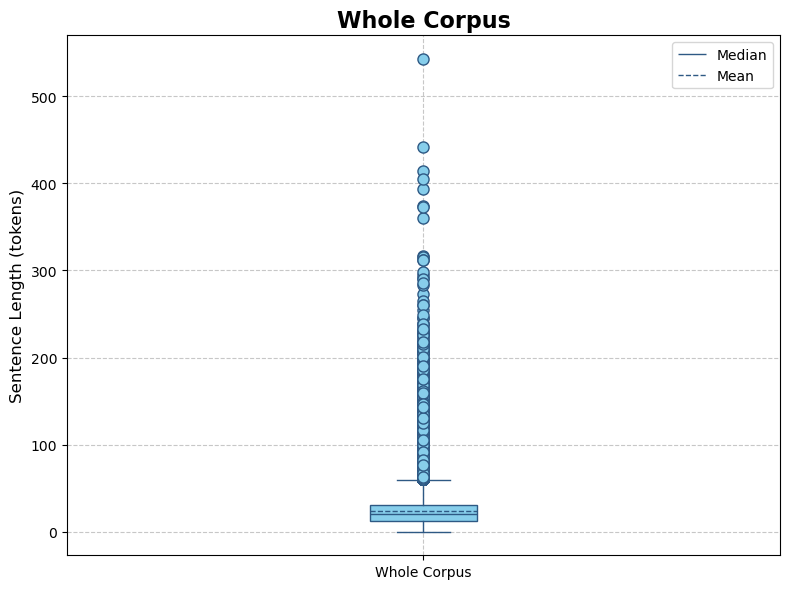

```python
corpus_data = [len(sentence) for sentence in corpus_tokens_list]
plot_custom_boxplot(corpus_data, "Whole Corpus")
```

## Final Remark

The corpus is prepared for use as input to train word embeddings.